# Project Investigate Dataset TMDB Movies Database

## Table of Content

- Introduction
- Data Wrangling
- Exploratory Data Analysis
- Conclusion

### Introduction

> This data set contains information about 10,000 movies collected from The Movie Database (TMDb), including user ratings and revenue. Looking at the Data, we have information about a movie's cast, genre, directors release date, ratings, budget and revenue. From my investigation of this dataset, I want to determine the:
- Statistical description on the Tmdb Datasets
- Top 10 movies with Highest Revenue
- How does the average voting change on the years
- How does the number of movies released changed over the years
- What are the properties that are associated with movies that has high revenue

> To Start the analysis of the TMDB Database, Let's import all relevant Packages

```python
# import all relevant packages for proje
import pandas as pd
import seaborn as sns
import numpy as np
import matplotlib.pyplot as plt
from matplotlib import dates as mpl_dates
%matplotlib inline
```

### Data Wrangling

> Let's start by accessing the first 10 rows and the last 10 rows of this Dataset. Also let's get information on the data types, missing values, duplicated values and so on to enable us have an overview information on the Data

```python
# Load the tmdb data with the name file tmdb-movies.csv
df = pd.read_csv('tmdb-movies.csv')
df.head(10)
```

|  | id | imdb_id | popularity | budget | revenue | original_title | cast | homepage | director | tagline | ... | overview | runtime | genres | production_companies | release_date | vote_count | vote_average | release_year | budget_adj | revenue_adj |
| --- | --- | --- | --- | --- | --- | --- | --- | --- | --- | --- | --- | --- | --- | --- | --- | --- | --- | --- | --- | --- | --- |
| 0 | 135397 | tt0369610 | 32.985763 | 150000000 | 1513528810 | Jurassic World | Chris Pratt\|Bryce Dallas Howard\|Irrfan Khan\|Vi... | http://www.jurassicworld.com/ | Colin Trevorrow | The park is open. | ... | Twenty-two years after the events of Jurassic ... | 124 | Action\|Adventure\|Science Fiction\|Thriller | Universal Studios\|Amblin Entertainment\|Legenda... | 6/9/15 | 5562 | 6.5 | 2015 | 1.379999e+08 | 1.392446e+09 |
| 1 | 76341 | tt1392190 | 28.419936 | 150000000 | 378436354 | Mad Max: Fury Road | Tom Hardy\|Charlize Theron\|Hugh Keays-Byrne\|Nic... | http://www.madmaxmovie.com/ | George Miller | What a Lovely Day. | ... | An apocalyptic story set in the furthest reach... | 120 | Action\|Adventure\|Science Fiction\|Thriller | Village Roadshow Pictures\|Kennedy Miller Produ... | 5/13/15 | 6185 | 7.1 | 2015 | 1.379999e+08 | 3.481613e+08 |
| 2 | 262500 | tt2908446 | 13.112507 | 110000000 | 295238201 | Insurgent | Shailene Woodley\|Theo James\|Kate Winslet\|Ansel... | http://www.thedivergentseries.movie/#insurgent | Robert Schwentke | One Choice Can Destroy You | ... | Beatrice Prior must confront her inner demons ... | 119 | Adventure\|Science Fiction\|Thriller | Summit Entertainment\|Mandeville Films\|Red Wago... | 3/18/15 | 2480 | 6.3 | 2015 | 1.012000e+08 | 2.716190e+08 |
| 3 | 140607 | tt2488496 | 11.173104 | 200000000 | 2068178225 | Star Wars: The Force Awakens | Harrison Ford\|Mark Hamill\|Carrie Fisher\|Adam D... | http://www.starwars.com/films/star-wars-episod... | J.J. Abrams | Every generation has a story. | ... | Thirty years after defeating the Galactic Empi... | 136 | Action\|Adventure\|Science Fiction\|Fantasy | Lucasfilm\|Truenorth Productions\|Bad Robot | 12/15/15 | 5292 | 7.5 | 2015 | 1.839999e+08 | 1.902723e+09 |
| 4 | 168259 | tt2820852 | 9.335014 | 190000000 | 1506249360 | Furious 7 | Vin Diesel\|Paul Walker\|Jason Statham\|Michelle ... | http://www.furious7.com/ | James Wan | Vengeance Hits Home | ... | Deckard Shaw seeks revenge against Dominic Tor... | 137 | Action\|Crime\|Thriller | Universal Pictures\|Original Film\|Media Rights ... | 4/1/15 | 2947 | 7.3 | 2015 | 1.747999e+08 | 1.385749e+09 |
| 5 | 281957 | tt1663202 | 9.110700 | 135000000 | 532950503 | The Revenant | Leonardo DiCaprio\|Tom Hardy\|Will Poulter\|Domhn... | http://www.foxmovies.com/movies/the-revenant | Alejandro González Iñárritu | (n. One who has returned, as if from the dead.) | ... | In the 1820s, a frontiersman, Hugh Glass, sets... | 156 | Western\|Drama\|Adventure\|Thriller | Regency Enterprises\|Appian Way\|CatchPlay\|Anony... | 12/25/15 | 3929 | 7.2 | 2015 | 1.241999e+08 | 4.903142e+08 |
| 6 | 87101 | tt1340138 | 8.654359 | 155000000 | 440603537 | Terminator Genisys | Arnold Schwarzenegger\|Jason Clarke\|Emilia Clar... | http://www.terminatormovie.com/ | Alan Taylor | Reset the future | ... | The year is 2029. John Connor, leader of the r... | 125 | Science Fiction\|Action\|Thriller\|Adventure | Paramount Pictures\|Skydance Productions | 6/23/15 | 2598 | 5.8 | 2015 | 1.425999e+08 | 4.053551e+08 |
| 7 | 286217 | tt3659388 | 7.667400 | 108000000 | 595380321 | The Martian | Matt Damon\|Jessica Chastain\|Kristen Wiig\|Jeff ... | http://www.foxmovies.com/movies/the-martian | Ridley Scott | Bring Him Home | ... | During a manned mission to Mars, Astronaut Mar... | 141 | Drama\|Adventure\|Science Fiction | Twentieth Century Fox Film Corporation\|Scott F... | 9/30/15 | 4572 | 7.6 | 2015 | 9.935996e+07 | 5.477497e+08 |
| 8 | 211672 | tt2293640 | 7.404165 | 74000000 | 1156730962 | Minions | Sandra Bullock\|Jon Hamm\|Michael Keaton\|Allison... | http://www.minionsmovie.com/ | Kyle Balda\|Pierre Coffin | Before Gru, they had a history of bad bosses | ... | Minions Stuart, Kevin and Bob are recruited by... | 91 | Family\|Animation\|Adventure\|Comedy | Universal Pictures\|Illumination Entertainment | 6/17/15 | 2893 | 6.5 | 2015 | 6.807997e+07 | 1.064192e+09 |
| 9 | 150540 | tt2096673 | 6.326804 | 175000000 | 853708609 | Inside Out | Amy Poehler\|Phyllis Smith\|Richard Kind\|Bill Ha... | http://movies.disney.com/inside-out | Pete Docter | Meet the little voices inside your head. | ... | Growing up can be a bumpy road, and it's no ex... | 94 | Comedy\|Animation\|Family | Walt Disney Pictures\|Pixar Animation Studios\|W... | 6/9/15 | 3935 | 8.0 | 2015 | 1.609999e+08 | 7.854116e+08 |

10 rows × 21 columns

```python
# Check the last 10 rows
df.tail(10)
```

|  | id | imdb_id | popularity | budget | revenue | original_title | cast | homepage | director | tagline | ... | overview | runtime | genres | production_companies | release_date | vote_count | vote_average | release_year | budget_adj | revenue_adj |
| --- | --- | --- | --- | --- | --- | --- | --- | --- | --- | --- | --- | --- | --- | --- | --- | --- | --- | --- | --- | --- | --- |
| 10856 | 20277 | tt0061135 | 0.140934 | 0 | 0 | The Ugly Dachshund | Dean Jones\|Suzanne Pleshette\|Charles Ruggles\|K... | NaN | Norman Tokar | A HAPPY HONEYMOON GOES TO THE DOGS!...When a G... | ... | The Garrisons (Dean Jones and Suzanne Pleshett... | 93 | Comedy\|Drama\|Family | Walt Disney Pictures | 2/16/66 | 14 | 5.7 | 1966 | 0.000000 | 0.0 |
| 10857 | 5921 | tt0060748 | 0.131378 | 0 | 0 | Nevada Smith | Steve McQueen\|Karl Malden\|Brian Keith\|Arthur K... | NaN | Henry Hathaway | Some called him savage- and some called him sa... | ... | Nevada Smith is the young son of an Indian mot... | 128 | Action\|Western | Paramount Pictures\|Solar Productions\|Embassy P... | 6/10/66 | 10 | 5.9 | 1966 | 0.000000 | 0.0 |
| 10858 | 31918 | tt0060921 | 0.317824 | 0 | 0 | The Russians Are Coming, The Russians Are Coming | Carl Reiner\|Eva Marie Saint\|Alan Arkin\|Brian K... | NaN | Norman Jewison | IT'S A PLOT! ...to make the world die laughing!! | ... | Without hostile intent, a Soviet sub runs agro... | 126 | Comedy\|War | The Mirisch Corporation | 5/25/66 | 11 | 5.5 | 1966 | 0.000000 | 0.0 |
| 10859 | 20620 | tt0060955 | 0.089072 | 0 | 0 | Seconds | Rock Hudson\|Salome Jens\|John Randolph\|Will Gee... | NaN | John Frankenheimer | NaN | ... | A secret organisation offers wealthy people a ... | 100 | Mystery\|Science Fiction\|Thriller\|Drama | Gibraltar Productions\|Joel Productions\|John Fr... | 10/5/66 | 22 | 6.6 | 1966 | 0.000000 | 0.0 |
| 10860 | 5060 | tt0060214 | 0.087034 | 0 | 0 | Carry On Screaming! | Kenneth Williams\|Jim Dale\|Harry H. Corbett\|Joa... | NaN | Gerald Thomas | Carry On Screaming with the Hilarious CARRY ON... | ... | The sinister Dr Watt has an evil scheme going.... | 87 | Comedy | Peter Rogers Productions\|Anglo-Amalgamated Fil... | 5/20/66 | 13 | 7.0 | 1966 | 0.000000 | 0.0 |
| 10861 | 21 | tt0060371 | 0.080598 | 0 | 0 | The Endless Summer | Michael Hynson\|Robert August\|Lord 'Tally Ho' B... | NaN | Bruce Brown | NaN | ... | The Endless Summer, by Bruce Brown, is one of ... | 95 | Documentary | Bruce Brown Films | 6/15/66 | 11 | 7.4 | 1966 | 0.000000 | 0.0 |
| 10862 | 20379 | tt0060472 | 0.065543 | 0 | 0 | Grand Prix | James Garner\|Eva Marie Saint\|Yves Montand\|Tosh... | NaN | John Frankenheimer | Cinerama sweeps YOU into a drama of speed and ... | ... | Grand Prix driver Pete Aron is fired by his te... | 176 | Action\|Adventure\|Drama | Cherokee Productions\|Joel Productions\|Douglas ... | 12/21/66 | 20 | 5.7 | 1966 | 0.000000 | 0.0 |
| 10863 | 39768 | tt0060161 | 0.065141 | 0 | 0 | Beregis Avtomobilya | Innokentiy Smoktunovskiy\|Oleg Efremov\|Georgi Z... | NaN | Eldar Ryazanov | NaN | ... | An insurance agent who moonlights as a carthie... | 94 | Mystery\|Comedy | Mosfilm | 1/1/66 | 11 | 6.5 | 1966 | 0.000000 | 0.0 |
| 10864 | 21449 | tt0061177 | 0.064317 | 0 | 0 | What's Up, Tiger Lily? | Tatsuya Mihashi\|Akiko Wakabayashi\|Mie Hama\|Joh... | NaN | Woody Allen | WOODY ALLEN STRIKES BACK! | ... | In comic Woody Allen's film debut, he took the... | 80 | Action\|Comedy | Benedict Pictures Corp. | 11/2/66 | 22 | 5.4 | 1966 | 0.000000 | 0.0 |
| 10865 | 22293 | tt0060666 | 0.035919 | 19000 | 0 | Manos: The Hands of Fate | Harold P. Warren\|Tom Neyman\|John Reynolds\|Dian... | NaN | Harold P. Warren | It's Shocking! It's Beyond Your Imagination! | ... | A family gets lost on the road and stumbles up... | 74 | Horror | Norm-Iris | 11/15/66 | 15 | 1.5 | 1966 | 127642.279154 | 0.0 |

10 rows × 21 columns

```python
# Print the number of rows and columns in tmdb movies dataset
print('rows in Tmdb Dataset: ', df.shape[0])
print('columns in Tmdb Dataset: ', df.shape[1])
```

```
rows in Tmdb Dataset:  10866
columns in Tmdb Dataset:  21
```

```python
# let's check for datatypes
df.dtypes
```

```
id                        int64
imdb_id                  object
popularity              float64
budget                    int64
revenue                   int64
original_title           object
cast                     object
homepage                 object
director                 object
tagline                  object
keywords                 object
overview                 object
runtime                   int64
genres                   object
production_companies     object
release_date             object
vote_count                int64
vote_average            float64
release_year              int64
budget_adj              float64
revenue_adj             float64
dtype: object
```

```python
# Check for columns info, null values in the data and the required memory for your datasets
df.info()
```

```
<class 'pandas.core.frame.DataFrame'>
RangeIndex: 10866 entries, 0 to 10865
Data columns (total 21 columns):
id                      10866 non-null int64
imdb_id                 10856 non-null object
popularity              10866 non-null float64
budget                  10866 non-null int64
revenue                 10866 non-null int64
original_title          10866 non-null object
cast                    10790 non-null object
homepage                2936 non-null object
director                10822 non-null object
tagline                 8042 non-null object
keywords                9373 non-null object
overview                10862 non-null object
runtime                 10866 non-null int64
genres                  10843 non-null object
production_companies    9836 non-null object
release_date            10866 non-null object
vote_count              10866 non-null int64
vote_average            10866 non-null float64
release_year            10866 non-null int64
budget_adj              10866 non-null float64
revenue_adj             10866 non-null float64
dtypes: float64(4), int64(6), object(11)
memory usage: 1.7+ MB
```

> Looking at the information above, the dataset has 10866 rows and 21 column. we have three data types which include integer, float and object. in the same vein, this info also shows there are nine(9) columns with null values. we are going to investigate this in the next few lines of codes

> Let's check for Missing , Duplicated and Uniques Values

```python
# Check for the total number of null values for each column
df.isnull().sum()
```

```
id                         0
imdb_id                   10
popularity                 0
budget                     0
revenue                    0
original_title             0
cast                      76
homepage                7930
director                  44
tagline                 2824
keywords                1493
overview                   4
runtime                    0
genres                    23
production_companies    1030
release_date               0
vote_count                 0
vote_average               0
release_year               0
budget_adj                 0
revenue_adj                0
dtype: int64
```

```python
# lets estimate the columns with highest percentage of missing values
Percentage_Missing = df.isnull().sum() * 100/len(df)
Percentage_Missing.sort_values(ascending=False)
```

```
homepage                72.979937
tagline                 25.989324
keywords                13.740107
production_companies     9.479109
cast                     0.699429
director                 0.404933
genres                   0.211669
imdb_id                  0.092030
overview                 0.036812
popularity               0.000000
budget                   0.000000
revenue                  0.000000
original_title           0.000000
revenue_adj              0.000000
budget_adj               0.000000
runtime                  0.000000
release_date             0.000000
vote_count               0.000000
vote_average             0.000000
release_year             0.000000
id                       0.000000
dtype: float64
```

#### This percentage arranged in descending order shows that the homepage has the highest number of missing values

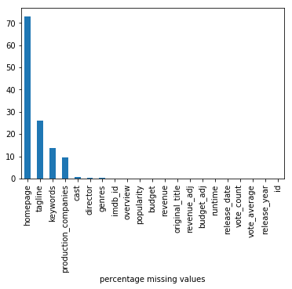

```python
# Lets also visualise the percentage of missing values
Percentage_Missing.sort_values(ascending=False).plot(kind = 'bar')
plt.xlabel('percentage missing values')
plt.show()
```

```python
# Check for Duplicated Values
df.duplicated().sum()
```

```
1
```

> Based on this investigation, only one duplicate was found which can be dropped

```python
# Check column for easy reference
df.columns
```

```
Index(['id', 'imdb_id', 'popularity', 'budget', 'revenue', 'original_title',
       'cast', 'homepage', 'director', 'tagline', 'keywords', 'overview',
       'runtime', 'genres', 'production_companies', 'release_date',
       'vote_count', 'vote_average', 'release_year', 'budget_adj',
       'revenue_adj'],
      dtype='object')
```

```python
# Check the overview of unique values for all the columns over the rows
df.nunique(axis=0)
```

```
id                      10865
imdb_id                 10855
popularity              10814
budget                    557
revenue                  4702
original_title          10571
cast                    10719
homepage                 2896
director                 5067
tagline                  7997
keywords                 8804
overview                10847
runtime                   247
genres                   2039
production_companies     7445
release_date             5909
vote_count               1289
vote_average               72
release_year               56
budget_adj               2614
revenue_adj              4840
dtype: int64
```

```python
df.director.nunique()
```

```
5067
```

```python
# Let create a function to find uniqe values for each columns so we can call this at any point during our code
def uni_values(column_Name):
    uni_val = set()
    for value in df[column_Name]:
        uni_val.add(value)

    return uni_val
```

```python
# lets test our function to see if its working
list1 = uni_values('vote_average')
```

```python
len(list1)
```

```
72
```

> From the unique values above, we can deduce that we release_ year columns has a couple of movies releases yearly, popularity has so many uniques which will be good for data analysis and investigation

### Data Cleaning

#### What do we need to Clean:

- Drop Unnecessary Column
- Change the data types to right format for easy future analysis
- Drop all duplicates

```python
df.columns
```

```
Index(['id', 'imdb_id', 'popularity', 'budget', 'revenue', 'original_title',
       'cast', 'homepage', 'director', 'tagline', 'keywords', 'overview',
       'runtime', 'genres', 'production_companies', 'release_date',
       'vote_count', 'vote_average', 'release_year', 'budget_adj',
       'revenue_adj'],
      dtype='object')
```

```python
 df.drop(columns = ['homepage', 'imdb_id', 'overview', 'tagline', 'production_companies', 'keywords'], inplace=True)
```

```python
# Confirm all required columns has been dropped
df.columns
```

```
Index(['id', 'popularity', 'budget', 'revenue', 'original_title', 'cast',
       'director', 'runtime', 'genres', 'release_date', 'vote_count',
       'vote_average', 'release_year', 'budget_adj', 'revenue_adj'],
      dtype='object')
```

```python
# change datatypes to required format for EDA
df.id = df.id.astype(str)
df.revenue = df.revenue.astype(float)
df.budget = df.budget.astype(float)
df.release_year = df.release_year.astype(str)
df.release_date = pd.to_datetime(df.release_date)
df['release_month']  = df.release_date.dt.month_name()
df['release_week_day']  = df.release_date.dt.day_name()
```

```python
#Confirm changes on data types and the two columns created
df.head(1)
```

|  | id | popularity | budget | revenue | original_title | cast | director | runtime | genres | release_date | vote_count | vote_average | release_year | budget_adj | revenue_adj | release_month | release_week_day |
| --- | --- | --- | --- | --- | --- | --- | --- | --- | --- | --- | --- | --- | --- | --- | --- | --- | --- |
| 0 | 135397 | 32.985763 | 150000000.0 | 1.513529e+09 | Jurassic World | Chris Pratt\|Bryce Dallas Howard\|Irrfan Khan\|Vi... | Colin Trevorrow | 124 | Action\|Adventure\|Science Fiction\|Thriller | 2015-06-09 | 5562 | 6.5 | 2015 | 1.379999e+08 | 1.392446e+09 | June | Tuesday |

```python
# check Datatypes
df.dtypes
```

```
id                          object
popularity                 float64
budget                     float64
revenue                    float64
original_title              object
cast                        object
director                    object
runtime                      int64
genres                      object
release_date        datetime64[ns]
vote_count                   int64
vote_average               float64
release_year                object
budget_adj                 float64
revenue_adj                float64
release_month               object
release_week_day            object
dtype: object
```

```python
# Drop duplicates
df = df.drop_duplicates()
```

```python
# confirm duplicates was succesfully removed
df.duplicated().sum()
```

```
0
```

```python
# drop null values for cast , director and genres
df.dropna(subset = ['cast', 'director', 'genres'], how='any', inplace=True)
```

```python
# confirm the null values has been dropped
df.isnull().sum()
```

```
id                  0
popularity          0
budget              0
revenue             0
original_title      0
cast                0
director            0
runtime             0
genres              0
release_date        0
vote_count          0
vote_average        0
release_year        0
budget_adj          0
revenue_adj         0
release_month       0
release_week_day    0
dtype: int64
```

```python
df.info()
```

```
<class 'pandas.core.frame.DataFrame'>
Int64Index: 10731 entries, 0 to 10865
Data columns (total 17 columns):
id                  10731 non-null object
popularity          10731 non-null float64
budget              10731 non-null float64
revenue             10731 non-null float64
original_title      10731 non-null object
cast                10731 non-null object
director            10731 non-null object
runtime             10731 non-null int64
genres              10731 non-null object
release_date        10731 non-null datetime64[ns]
vote_count          10731 non-null int64
vote_average        10731 non-null float64
release_year        10731 non-null object
budget_adj          10731 non-null float64
revenue_adj         10731 non-null float64
release_month       10731 non-null object
release_week_day    10731 non-null object
dtypes: datetime64[ns](1), float64(6), int64(2), object(8)
memory usage: 1.5+ MB
```

### Exploratory Analysis and Research Questions

> Question 1: Statistical Description of the Tmdb Dataset

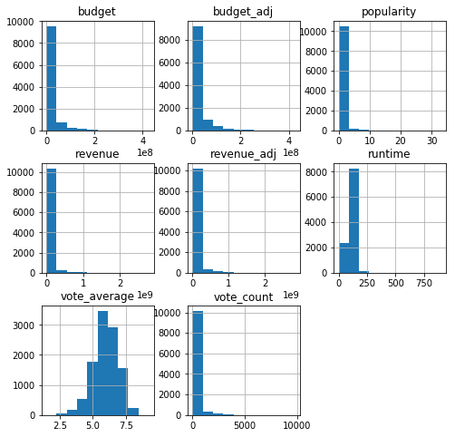

```python
df.hist(figsize = (8,8))
plt.title('Distributions of TMDB Data')
plt.show()
```

```python
df.describe()
```

|  | popularity | budget | revenue | runtime | vote_count | vote_average | budget_adj | revenue_adj |
| --- | --- | --- | --- | --- | --- | --- | --- | --- |
| count | 10731.000000 | 1.073100e+04 | 1.073100e+04 | 10731.000000 | 10731.000000 | 10731.000000 | 1.073100e+04 | 1.073100e+04 |
| mean | 0.652615 | 1.480365e+07 | 4.031989e+07 | 102.468829 | 219.812972 | 5.964710 | 1.776530e+07 | 5.200623e+07 |
| std | 1.004804 | 3.106456e+07 | 1.176524e+08 | 30.493873 | 578.815324 | 0.930283 | 3.446630e+07 | 1.454252e+08 |
| min | 0.000188 | 0.000000e+00 | 0.000000e+00 | 0.000000 | 10.000000 | 1.500000 | 0.000000e+00 | 0.000000e+00 |
| 25% | 0.210765 | 0.000000e+00 | 0.000000e+00 | 90.000000 | 17.000000 | 5.400000 | 0.000000e+00 | 0.000000e+00 |
| 50% | 0.387081 | 0.000000e+00 | 0.000000e+00 | 99.000000 | 39.000000 | 6.000000 | 0.000000e+00 | 0.000000e+00 |
| 75% | 0.720889 | 1.600000e+07 | 2.500000e+07 | 112.000000 | 148.000000 | 6.600000 | 2.110885e+07 | 3.470546e+07 |
| max | 32.985763 | 4.250000e+08 | 2.781506e+09 | 900.000000 | 9767.000000 | 9.200000 | 4.250000e+08 | 2.827124e+09 |

> The Descriptive statistics above shows that we the budget, revenue , budget_adj, revenue_adj has high proportion of his values equal to zero.. we will response to question around this in this study

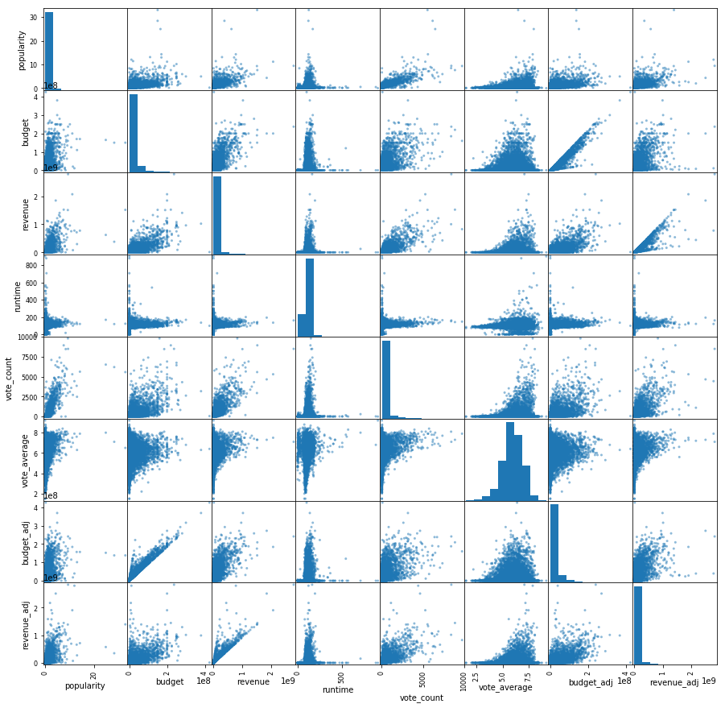

```python
pd.plotting.scatter_matrix(df, alpha= 0.5, figsize = (15, 15));
```

### Let's check for relationship between columns

```python
corr_df = df.corr()
corr_df
```

|  | popularity | budget | revenue | runtime | vote_count | vote_average | budget_adj | revenue_adj |
| --- | --- | --- | --- | --- | --- | --- | --- | --- |
| popularity | 1.000000 | 0.544240 | 0.662843 | 0.138278 | 0.800619 | 0.217906 | 0.512098 | 0.608384 |
| budget | 0.544240 | 1.000000 | 0.734487 | 0.192168 | 0.632074 | 0.087318 | 0.968881 | 0.621809 |
| revenue | 0.662843 | 0.734487 | 1.000000 | 0.164276 | 0.790889 | 0.178477 | 0.705949 | 0.918990 |
| runtime | 0.138278 | 0.192168 | 0.164276 | 1.000000 | 0.164966 | 0.177276 | 0.222645 | 0.177397 |
| vote_count | 0.800619 | 0.632074 | 0.790889 | 0.164966 | 1.000000 | 0.260554 | 0.586298 | 0.707517 |
| vote_average | 0.217906 | 0.087318 | 0.178477 | 0.177276 | 0.260554 | 1.000000 | 0.099925 | 0.199418 |
| budget_adj | 0.512098 | 0.968881 | 0.705949 | 0.222645 | 0.586298 | 0.099925 | 1.000000 | 0.645937 |
| revenue_adj | 0.608384 | 0.621809 | 0.918990 | 0.177397 | 0.707517 | 0.199418 | 0.645937 | 1.000000 |

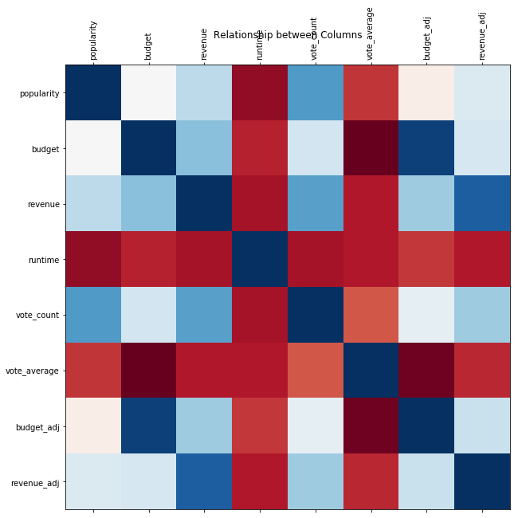

```python
# Plot correlation plots to get information on relationship between column
fig = plt.figure(figsize = (15,10))
plt.matshow(corr_df, fignum =  fig.number, cmap = 'RdBu')
plt.title('Relationship between Columns')
plt.xticks(range(len(corr_df.columns)), corr_df.columns, rotation= 'vertical');
plt.yticks(range(len(corr_df.columns)), corr_df.columns);
```

> Question 2 : Top 10 movies with the Highest Revenue

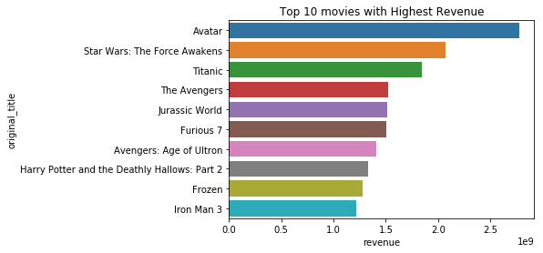

```python
# extract movies with the highest revenue
top_10_revenue =df.sort_values('revenue', ascending=False).head(10)

# Visualize the selected movies with Highest revenues
sns.barplot(x = 'revenue', y= 'original_title', data = top_10_revenue)
plt.title('Top 10 movies with Highest Revenue')
plt.show()
```

> This is a bar plot showing the top 10 movies with highest revenue. this shows that avatar generated a high revenue relative to other movies. Here we can really say much on why we have this but we will investigate this in subsequent codes by checking the properties that contribute to revenue or profitability of the movies. we can also see the least 3 movies out of the top 10 generated almost the same revenue..we can as well check for similar properties amongst this 3 movies if required

> Question 3 : How did the voting changed over the years

```python
df.columns
```

```
Index(['id', 'popularity', 'budget', 'revenue', 'original_title', 'cast',
       'director', 'runtime', 'genres', 'release_date', 'vote_count',
       'vote_average', 'release_year', 'budget_adj', 'revenue_adj',
       'release_month', 'release_week_day'],
      dtype='object')
```

```python
# Select Data to estimate mean average
av_voting = df.groupby('release_year')['vote_average'].mean();
```

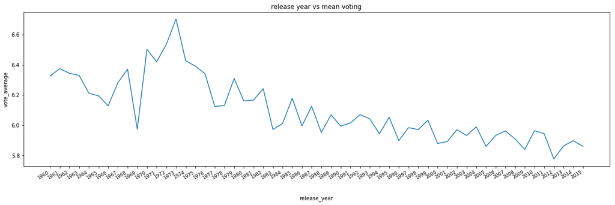

```python
# plot release_year vs average vote_average
plt.figure(figsize=(20, 6))
plt.plot(av_voting.index, av_voting)
# over x labels overlapping
plt.gcf().autofmt_xdate()
# title and labels
plt.title('release year vs mean voting')
plt.xticks(fontsize = 9)
plt.xlabel('release_year', labelpad= 30)
plt.ylabel('vote_average');
```

#### The chart aboves shows the mean voting had a peak mean votes between 1973 and 1975 and after this we had a fluctuation in rise and falls of the mean votes. this can be as a result of the number of movies released yearly or some other factors which will require further verification

> Question 4: How does the numbers of release movies changed over the years

```python
df['release_year'].value_counts()
```

```
2014    682
2013    649
2015    617
2012    574
2011    532
2009    525
2008    486
2010    475
2007    432
2006    404
2005    361
2004    307
2003    281
2002    264
2001    241
```

[output cut: 42 more lines]

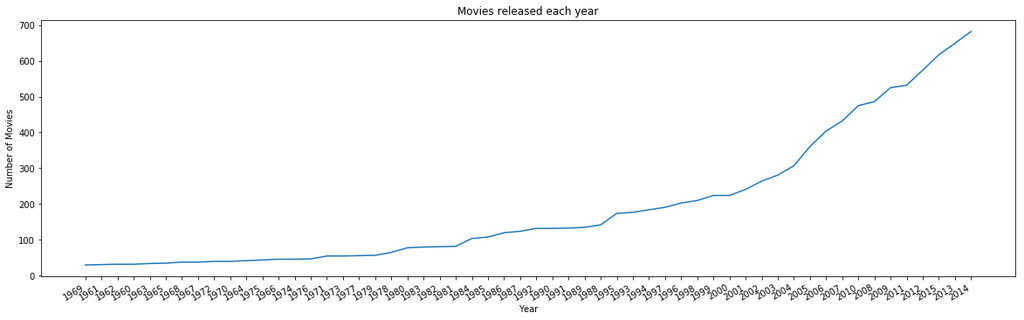

```python
release_each_year = df['release_year'].value_counts().sort_values(ascending= True)
plt.figure(figsize=(20,6))
plt.plot(release_each_year)
plt.title('Movies released each year', loc = 'center')
plt.gcf().autofmt_xdate()
plt.xlabel('Year')
plt.ylabel('Number of Movies')
plt.show()
```

> Questions 5: What are the properties that are associated with movies that has high revenue

```python
# let check the title of the movie with highest revenue

df[df['revenue'].max() == df['revenue']]['original_title']
```

```
1386    Avatar
Name: original_title, dtype: object
```

```python
# Does movies with high popularity receive high revenue
median = df['popularity'].median()
low = df.query('popularity < {}'.format(median))
high = df.query('popularity >= {}'.format(median))

mean_revenue_low = low['revenue'].mean()
mean_revenue_high = high['revenue'].mean()
```

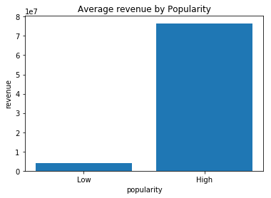

```python
# let visualise the data to see the effect of popularity on revenue
loc = [1, 2]
heights = [mean_revenue_low, mean_revenue_high]
labels = ['Low', 'High']
plt.bar(loc, heights, tick_label=labels)
plt.title('Average revenue by Popularity')
plt.xlabel('popularity')
plt.ylabel('revenue');
```

```python
df.columns
```

```
Index(['id', 'popularity', 'budget', 'revenue', 'original_title', 'cast',
       'director', 'runtime', 'genres', 'release_date', 'vote_count',
       'vote_average', 'release_year', 'budget_adj', 'revenue_adj',
       'release_month', 'release_week_day'],
      dtype='object')
```

```python
# Does high budget movies bring more revenue
# from the Data Statistics, we already know budget has alot of zero values, so let use the top 10 percent value for our prediction
a = df['budget']
percent = np.percentile(a, 90)
low = df.query('budget < {}'.format(percent))
high = df.query('budget >= {}'.format(percent))

mean_revenue_low = low['revenue'].mean()
mean_revenue_high = high['revenue'].mean()
```

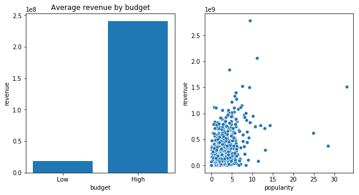

```python
# let visualise the data to see the effect of popularity on revenue
loc = [1, 2]
heights = [mean_revenue_low, mean_revenue_high]
labels = ['Low', 'High']
plt.figure(figsize=(10,5))
plt.subplot(1,2,1)
plt.bar(loc, heights, tick_label=labels)
plt.title('Average revenue by budget')
plt.xlabel('budget')
plt.ylabel('revenue');

plt.subplot(1,2,2)
sns.scatterplot(x= 'popularity', y= 'revenue', data = df)
plt.show()
```

```python
mean_revenue_by_vote_average = df.groupby('vote_average').mean()['revenue']
mean_revenue_by_vote_average;
```

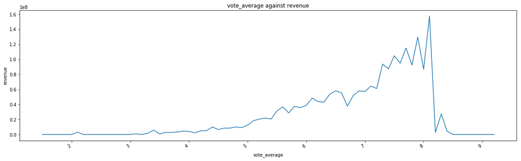

```python
# Plot vote_average against revenue generated
plt.figure(figsize = (20,6))
plt.plot(mean_revenue_by_vote_average.index, mean_revenue_by_vote_average)
plt.gcf().autofmt_xdate()
plt.title('vote_average against revenue')
plt.xlabel('vote_average', labelpad = 10)
plt.ylabel('revenue')
plt.show()
```

### Looking at the chart above, we can see increase in revenue as the average voting increase from (4-8) ratings and we had a peak between 8 and the rating of 8.5..Also the movie with ratings of 2 to 4 generated almost the same revenue

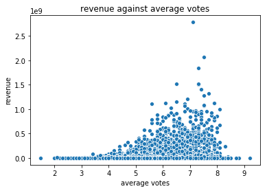

```python
# Does voting_average affect the revenue
sns.scatterplot(x= 'vote_average', y= 'revenue', data = df)
plt.title('revenue against average votes')
plt.xlabel('average votes')
plt.ylabel('revenue')
plt.show()
```

```python
# lets also investigate the data where revenue is equivalent to zero

zero_revenue = df[df['revenue'] == 0]
zero_revenue
```

|  | id | popularity | budget | revenue | original_title | cast | director | runtime | genres | release_date | vote_count | vote_average | release_year | budget_adj | revenue_adj | release_month | release_week_day |
| --- | --- | --- | --- | --- | --- | --- | --- | --- | --- | --- | --- | --- | --- | --- | --- | --- | --- |
| 48 | 265208 | 2.932340 | 30000000.0 | 0.0 | Wild Card | Jason Statham\|Michael Angarano\|Milo Ventimigli... | Simon West | 92 | Thriller\|Crime\|Drama | 2015-01-14 | 481 | 5.3 | 2015 | 2.759999e+07 | 0.0 | January | Wednesday |
| 67 | 334074 | 2.331636 | 20000000.0 | 0.0 | Survivor | Pierce Brosnan\|Milla Jovovich\|Dylan McDermott\|... | James McTeigue | 96 | Crime\|Thriller\|Action | 2015-05-21 | 280 | 5.4 | 2015 | 1.839999e+07 | 0.0 | May | Thursday |
| 74 | 347096 | 2.165433 | 0.0 | 0.0 | Mythica: The Darkspore | Melanie Stone\|Kevin Sorbo\|Adam Johnson\|Jake St... | Anne K. Black | 108 | Action\|Adventure\|Fantasy | 2015-06-24 | 27 | 5.1 | 2015 | 0.000000e+00 | 0.0 | June | Wednesday |
| 75 | 308369 | 2.141506 | 0.0 | 0.0 | Me and Earl and the Dying Girl | Thomas Mann\|RJ Cyler\|Olivia Cooke\|Connie Britt... | Alfonso Gomez-Rejon | 105 | Comedy\|Drama | 2015-06-12 | 569 | 7.7 | 2015 | 0.000000e+00 | 0.0 | June | Friday |
| 92 | 370687 | 1.876037 | 0.0 | 0.0 | Mythica: The Necromancer | Melanie Stone\|Adam Johnson\|Kevin Sorbo\|Nicola ... | A. Todd Smith | 0 | Fantasy\|Action\|Adventure | 2015-12-19 | 11 | 5.4 | 2015 | 0.000000e+00 | 0.0 | December | Saturday |
| 93 | 307663 | 1.872696 | 10000000.0 | 0.0 | Vice | Ambyr Childers\|Thomas Jane\|Bryan Greenberg\|Bru... | Brian A Miller | 96 | Thriller\|Science Fiction\|Action\|Adventure | 2015-01-16 | 181 | 4.1 | 2015 | 9.199996e+06 | 0.0 | January | Friday |
| 100 | 326359 | 1.724712 | 0.0 | 0.0 | Frozen Fever | Kristen Bell\|Idina Menzel\|Jonathan Groff\|Josh ... | Chris Buck\|Jennifer Lee | 8 | Adventure\|Animation\|Family | 2015-03-09 | 475 | 7.0 | 2015 | 0.000000e+00 | 0.0 | March | Monday |
| 101 | 254302 | 1.661789 | 0.0 | 0.0 | High-Rise | Tom Hiddleston\|Sienna Miller\|Jeremy Irons\|Luke... | Ben Wheatley | 119 | Action\|Drama\|Science Fiction | 2015-09-26 | 161 | 5.4 | 2015 | 0.000000e+00 | 0.0 | September | Saturday |
| 103 | 292040 | 1.646664 | 0.0 | 0.0 | Spooks: The Greater Good | Peter Firth\|Kit Harington\|Jennifer Ehle\|Lara P... | Bharat Nalluri | 104 | Thriller\|Action | 2015-04-11 | 114 | 5.6 | 2015 | 0.000000e+00 | 0.0 | April | Saturday |
| 116 | 297291 | 1.380320 | 0.0 | 0.0 | The Scorpion King: The Lost Throne | Victor Webster\|Ellen Hollman\|Barry Bostwick\|Wi... | Mike Elliott | 105 | Action\|Fantasy\|Adventure | 2015-01-09 | 22 | 4.5 | 2015 | 0.000000e+00 | 0.0 | January | Friday |
| 122 | 277355 | 1.342839 | 0.0 | 0.0 | Everly | Salma Hayek\|Hiroyuki Watanabe\|Jennifer Blanc\|T... | Joe Lynch | 90 | Thriller\|Action | 2015-01-23 | 169 | 5.1 | 2015 | 0.000000e+00 | 0.0 | January | Friday |
| 133 | 157827 | 1.251681 | 11000000.0 | 0.0 | Louder Than Bombs | Gabriel Byrne\|Isabelle Huppert\|Jesse Eisenberg... | Joachim Trier | 109 | Drama | 2015-05-18 | 43 | 6.3 | 2015 | 1.012000e+07 | 0.0 | May | Monday |
| 140 | 300803 | 1.144808 | 0.0 | 0.0 | Dragonheart 3: The Sorcerer's Curse | Julian Morris\|Tamzin Merchant\|Jassa Ahluwalia\|... | Colin Teague | 97 | Action\|Adventure\|Fantasy | 2015-02-24 | 59 | 4.5 | 2015 | 0.000000e+00 | 0.0 | February | Tuesday |
| 143 | 378373 | 1.128081 | 0.0 | 0.0 | Brothers of the Wind | Manuel Camacho\|Jean Reno\|Tobias Moretti\|Eva Kuen | Gerado Olivares\|Otmar Penker | 98 | Adventure\|Drama\|Family | 2015-12-24 | 11 | 7.5 | 2015 | 0.000000e+00 | 0.0 | December | Thursday |
| 145 | 294963 | 1.073349 | 1800000.0 | 0.0 | Bone Tomahawk | Kurt Russell\|Richard Jenkins\|Matthew Fox\|Lili ... | S. Craig Zahler | 132 | Horror\|Western\|Adventure\|Drama | 2015-10-23 | 220 | 6.3 | 2015 | 1.655999e+06 | 0.0 | October | Friday |
| 147 | 245698 | 1.063055 | 0.0 | 0.0 | Pawn Sacrifice | Tobey Maguire\|Lily Rabe\|Peter Sarsgaard\|Liev S... | Edward Zwick | 114 | Drama | 2015-09-16 | 148 | 6.6 | 2015 | 0.000000e+00 | 0.0 | September | Wednesday |
| 149 | 346808 | 1.041922 | 20000000.0 | 0.0 | Momentum | Olga Kurylenko\|Morgan Freeman\|James Purefoy\|Je... | Stephen S. Campanelli | 96 | Thriller\|Action | 2015-08-01 | 100 | 5.8 | 2015 | 1.839999e+07 | 0.0 | August | Saturday |
| 151 | 290637 | 1.036825 | 0.0 | 0.0 | Pay the Ghost | Nicolas Cage\|Sarah Wayne Callies\|Veronica Ferr... | Uli Edel | 94 | Horror\|Thriller | 2015-09-16 | 114 | 5.3 | 2015 | 0.000000e+00 | 0.0 | September | Wednesday |
| 152 | 244458 | 1.027620 | 0.0 | 0.0 | The Voices | Ryan Reynolds\|Gemma Arterton\|Anna Kendrick\|Jac... | Marjane Satrapi | 101 | Horror\|Thriller\|Comedy\|Crime | 2015-02-06 | 371 | 6.0 | 2015 | 0.000000e+00 | 0.0 | February | Friday |
| 154 | 314405 | 1.008474 | 12000000.0 | 0.0 | Il racconto dei racconti | Salma Hayek\|Vincent Cassel\|John C. Reilly\|Toby... | Matteo Garrone | 125 | Romance\|Fantasy\|Horror | 2015-05-14 | 211 | 5.7 | 2015 | 1.104000e+07 | 0.0 | May | Thursday |
| 156 | 157843 | 0.973316 | 15000000.0 | 0.0 | Queen of the Desert | Nicole Kidman\|James Franco\|Robert Pattinson\|Da... | Werner Herzog | 128 | Drama\|History | 2015-09-03 | 30 | 6.0 | 2015 | 1.379999e+07 | 0.0 | September | Thursday |
| 158 | 290762 | 0.953647 | 0.0 | 0.0 | Miss You Already | Drew Barrymore\|Toni Collette\|Dominic Cooper\|Ja... | Catherine Hardwicke | 112 | Comedy\|Drama\|Romance | 2015-09-12 | 139 | 7.2 | 2015 | 0.000000e+00 | 0.0 | September | Saturday |
| 159 | 251516 | 0.953046 | 630019.0 | 0.0 | Kung Fury | David Sandberg\|Jorma Taccone\|Leopold Nilsson\|A... | David Sandberg | 31 | Action\|Comedy\|Science Fiction\|Fantasy | 2015-05-28 | 487 | 7.7 | 2015 | 5.796172e+05 | 0.0 | May | Thursday |
| 164 | 228968 | 0.917040 | 0.0 | 0.0 | Kidnapping Mr. Heineken | Anthony Hopkins\|Jim Sturgess\|Sam Worthington\|R... | Daniel Alfredson | 95 | Drama\|Action\|Crime\|Thriller | 2015-03-12 | 131 | 5.8 | 2015 | 0.000000e+00 | 0.0 | March | Thursday |
| 165 | 347969 | 0.913085 | 60000000.0 | 0.0 | The Ridiculous 6 | Adam Sandler\|Taylor Lautner\|Steve Buscemi\|Terr... | Frank Coraci | 119 | Comedy\|Western | 2015-12-11 | 252 | 4.8 | 2015 | 5.519998e+07 | 0.0 | December | Friday |
| 166 | 237756 | 0.906860 | 0.0 | 0.0 | Kill Me Three Times | Teresa Palmer\|Simon Pegg\|Luke Hemsworth\|Sulliv... | Kriv Stenders | 90 | Comedy\|Thriller | 2015-04-10 | 96 | 5.1 | 2015 | 0.000000e+00 | 0.0 | April | Friday |
| 169 | 311291 | 0.894477 | 0.0 | 0.0 | 45 Years | Charlotte Rampling\|Tom Courtenay\|Dolly Wells\|G... | Andrew Haigh | 95 | Drama | 2015-08-28 | 167 | 6.0 | 2015 | 0.000000e+00 | 0.0 | August | Friday |
| 174 | 342474 | 0.861179 | 0.0 | 0.0 | Jenny's Wedding | Katherine Heigl\|Tom Wilkinson\|Alexis Bledel\|Gr... | Mary Agnes Donoghue | 94 | Comedy\|Drama | 2015-07-31 | 92 | 5.2 | 2015 | 0.000000e+00 | 0.0 | July | Friday |
| 175 | 277217 | 0.848748 | 0.0 | 0.0 | Descendants | Booboo Stewart\|Dove Cameron\|Keegan Connor Trac... | Kenny Ortega | 112 | Music\|Action\|Adventure\|Comedy\|Family | 2015-07-31 | 262 | 6.7 | 2015 | 0.000000e+00 | 0.0 | July | Friday |
| 176 | 207936 | 0.843174 | 0.0 | 0.0 | Tumbledown | Joe Manganiello\|Jason Sudeikis\|Blythe Danner\|R... | Sean Mewshaw | 105 | Music\|Romance\|Comedy | 2015-04-18 | 22 | 6.6 | 2015 | 0.000000e+00 | 0.0 | April | Saturday |
| ... | ... | ... | ... | ... | ... | ... | ... | ... | ... | ... | ... | ... | ... | ... | ... | ... | ... |
| 10834 | 12639 | 0.310688 | 0.0 | 0.0 | Return of the Seven | Yul Brynner\|Robert Fuller\|JuliÃ¡n Mateos\|Warre... | Burt Kennedy | 95 | Action\|Western | 2066-10-19 | 14 | 5.1 | 1966 | 0.000000e+00 | 0.0 | October | Tuesday |
| 10836 | 38720 | 0.239435 | 0.0 | 0.0 | Walk Don't Run | Cary Grant\|Samantha Eggar\|Jim Hutton\|John Stan... | Charles Walters | 114 | Comedy\|Romance | 2066-01-01 | 11 | 5.8 | 1966 | 0.000000e+00 | 0.0 | January | Friday |
| 10837 | 19728 | 0.291704 | 0.0 | 0.0 | The Blue Max | George Peppard\|James Mason\|Ursula Andress\|Jere... | John Guillermin | 156 | War\|Action\|Adventure\|Drama | 2066-06-21 | 12 | 5.5 | 1966 | 0.000000e+00 | 0.0 | June | Monday |
| 10838 | 22383 | 0.151845 | 0.0 | 0.0 | The Professionals | Burt Lancaster\|Lee Marvin\|Robert Ryan\|Woody St... | Richard Brooks | 117 | Action\|Adventure\|Western | 2066-11-01 | 21 | 6.0 | 1966 | 0.000000e+00 | 0.0 | November | Monday |
| 10839 | 13353 | 0.276133 | 0.0 | 0.0 | It's the Great Pumpkin, Charlie Brown | Christopher Shea\|Sally Dryer\|Kathy Steinberg\|A... | Bill Melendez | 25 | Family\|Animation | 2066-10-27 | 49 | 7.2 | 1966 | 0.000000e+00 | 0.0 | October | Wednesday |
| 10840 | 34388 | 0.102530 | 0.0 | 0.0 | Funeral in Berlin | Michael Caine\|Paul Hubschmid\|Oskar Homolka\|Eva... | Guy Hamilton | 102 | Thriller | 2066-12-22 | 13 | 5.7 | 1966 | 0.000000e+00 | 0.0 | December | Wednesday |
| 10841 | 42701 | 0.264925 | 75000.0 | 0.0 | The Shooting | Will Hutchins\|Millie Perkins\|Jack Nicholson\|Wa... | Monte Hellman | 82 | Western | 2066-10-23 | 12 | 5.5 | 1966 | 5.038511e+05 | 0.0 | October | Saturday |
| 10842 | 36540 | 0.253437 | 0.0 | 0.0 | Winnie the Pooh and the Honey Tree | Sterling Holloway\|Junius Matthews\|Sebastian Ca... | Wolfgang Reitherman | 25 | Animation\|Family | 2066-01-01 | 12 | 7.9 | 1966 | 0.000000e+00 | 0.0 | January | Friday |
| 10843 | 29710 | 0.252399 | 0.0 | 0.0 | Khartoum | Charlton Heston\|Laurence Olivier\|Richard Johns... | Basil Dearden\|Eliot Elisofon | 134 | Adventure\|Drama\|War\|History\|Action | 2066-06-09 | 12 | 5.8 | 1966 | 0.000000e+00 | 0.0 | June | Wednesday |
| 10844 | 23728 | 0.236098 | 0.0 | 0.0 | Our Man Flint | James Coburn\|Lee J. Cobb\|Gila Golan\|Edward Mul... | Daniel Mann | 108 | Adventure\|Comedy\|Fantasy\|Science Fiction | 2066-01-16 | 13 | 5.6 | 1966 | 0.000000e+00 | 0.0 | January | Saturday |
| 10845 | 5065 | 0.230873 | 0.0 | 0.0 | Carry On Cowboy | Sid James\|Jim Dale\|Angela Douglas\|Kenneth Will... | Gerald Thomas | 93 | Comedy\|Western | 2066-03-01 | 15 | 5.9 | 1966 | 0.000000e+00 | 0.0 | March | Monday |
| 10846 | 17102 | 0.212716 | 0.0 | 0.0 | Dracula: Prince of Darkness | Christopher Lee\|Barbara Shelley\|Andrew Keir\|Fr... | Terence Fisher | 90 | Horror | 2066-01-09 | 16 | 5.7 | 1966 | 0.000000e+00 | 0.0 | January | Saturday |
| 10847 | 28763 | 0.034555 | 0.0 | 0.0 | Island of Terror | Peter Cushing\|Edward Judd\|Carole Gray\|Eddie By... | Terence Fisher | 89 | Science Fiction\|Horror | 2066-06-20 | 13 | 5.3 | 1966 | 0.000000e+00 | 0.0 | June | Sunday |
| 10849 | 28270 | 0.206537 | 0.0 | 0.0 | Gambit | Michael Caine\|Shirley MacLaine\|Herbert Lom\|Joh... | Ronald Neame | 109 | Action\|Comedy\|Crime | 2066-12-16 | 14 | 6.1 | 1966 | 0.000000e+00 | 0.0 | December | Thursday |
| 10850 | 26268 | 0.202473 | 0.0 | 0.0 | Harper | Paul Newman\|Lauren Bacall\|Julie Harris\|Arthur ... | Jack Smight | 121 | Action\|Drama\|Thriller\|Crime\|Mystery | 2066-02-23 | 14 | 6.0 | 1966 | 0.000000e+00 | 0.0 | February | Tuesday |
| 10851 | 15347 | 0.342791 | 0.0 | 0.0 | Born Free | Virginia McKenna\|Bill Travers\|Geoffrey Keen\|Pe... | James Hill | 95 | Adventure\|Drama\|Action\|Family\|Foreign | 2066-06-22 | 15 | 6.6 | 1966 | 0.000000e+00 | 0.0 | June | Tuesday |
| 10852 | 37301 | 0.227220 | 0.0 | 0.0 | A Big Hand for the Little Lady | Henry Fonda\|Joanne Woodward\|Jason Robards\|Paul... | Fielder Cook | 95 | Western | 2066-05-31 | 11 | 6.0 | 1966 | 0.000000e+00 | 0.0 | May | Monday |
| 10853 | 15598 | 0.163592 | 0.0 | 0.0 | Alfie | Michael Caine\|Shelley Winters\|Millicent Martin... | Lewis Gilbert | 114 | Comedy\|Drama\|Romance | 2066-03-29 | 26 | 6.2 | 1966 | 0.000000e+00 | 0.0 | March | Monday |
| 10854 | 31602 | 0.146402 | 0.0 | 0.0 | The Chase | Marlon Brando\|Jane Fonda\|Robert Redford\|E.G. M... | Arthur Penn | 135 | Thriller\|Drama\|Crime | 2066-02-17 | 17 | 6.0 | 1966 | 0.000000e+00 | 0.0 | February | Wednesday |
| 10855 | 13343 | 0.141026 | 700000.0 | 0.0 | The Ghost & Mr. Chicken | Don Knotts\|Joan Staley\|Liam Redmond\|Dick Sarge... | Alan Rafkin | 90 | Comedy\|Family\|Mystery\|Romance | 2066-01-20 | 14 | 6.1 | 1966 | 4.702610e+06 | 0.0 | January | Wednesday |
| 10856 | 20277 | 0.140934 | 0.0 | 0.0 | The Ugly Dachshund | Dean Jones\|Suzanne Pleshette\|Charles Ruggles\|K... | Norman Tokar | 93 | Comedy\|Drama\|Family | 2066-02-16 | 14 | 5.7 | 1966 | 0.000000e+00 | 0.0 | February | Tuesday |
| 10857 | 5921 | 0.131378 | 0.0 | 0.0 | Nevada Smith | Steve McQueen\|Karl Malden\|Brian Keith\|Arthur K... | Henry Hathaway | 128 | Action\|Western | 2066-06-10 | 10 | 5.9 | 1966 | 0.000000e+00 | 0.0 | June | Thursday |
| 10858 | 31918 | 0.317824 | 0.0 | 0.0 | The Russians Are Coming, The Russians Are Coming | Carl Reiner\|Eva Marie Saint\|Alan Arkin\|Brian K... | Norman Jewison | 126 | Comedy\|War | 2066-05-25 | 11 | 5.5 | 1966 | 0.000000e+00 | 0.0 | May | Tuesday |
| 10859 | 20620 | 0.089072 | 0.0 | 0.0 | Seconds | Rock Hudson\|Salome Jens\|John Randolph\|Will Gee... | John Frankenheimer | 100 | Mystery\|Science Fiction\|Thriller\|Drama | 2066-10-05 | 22 | 6.6 | 1966 | 0.000000e+00 | 0.0 | October | Tuesday |
| 10860 | 5060 | 0.087034 | 0.0 | 0.0 | Carry On Screaming! | Kenneth Williams\|Jim Dale\|Harry H. Corbett\|Joa... | Gerald Thomas | 87 | Comedy | 2066-05-20 | 13 | 7.0 | 1966 | 0.000000e+00 | 0.0 | May | Thursday |
| 10861 | 21 | 0.080598 | 0.0 | 0.0 | The Endless Summer | Michael Hynson\|Robert August\|Lord 'Tally Ho' B... | Bruce Brown | 95 | Documentary | 2066-06-15 | 11 | 7.4 | 1966 | 0.000000e+00 | 0.0 | June | Tuesday |
| 10862 | 20379 | 0.065543 | 0.0 | 0.0 | Grand Prix | James Garner\|Eva Marie Saint\|Yves Montand\|Tosh... | John Frankenheimer | 176 | Action\|Adventure\|Drama | 2066-12-21 | 20 | 5.7 | 1966 | 0.000000e+00 | 0.0 | December | Tuesday |
| 10863 | 39768 | 0.065141 | 0.0 | 0.0 | Beregis Avtomobilya | Innokentiy Smoktunovskiy\|Oleg Efremov\|Georgi Z... | Eldar Ryazanov | 94 | Mystery\|Comedy | 2066-01-01 | 11 | 6.5 | 1966 | 0.000000e+00 | 0.0 | January | Friday |
| 10864 | 21449 | 0.064317 | 0.0 | 0.0 | What's Up, Tiger Lily? | Tatsuya Mihashi\|Akiko Wakabayashi\|Mie Hama\|Joh... | Woody Allen | 80 | Action\|Comedy | 2066-11-02 | 22 | 5.4 | 1966 | 0.000000e+00 | 0.0 | November | Tuesday |
| 10865 | 22293 | 0.035919 | 19000.0 | 0.0 | Manos: The Hands of Fate | Harold P. Warren\|Tom Neyman\|John Reynolds\|Dian... | Harold P. Warren | 74 | Horror | 2066-11-15 | 15 | 1.5 | 1966 | 1.276423e+05 | 0.0 | November | Monday |

5888 rows × 17 columns

```python
# Let estimate proportion of our data that has zero revenue

propor_zero_revenue = len(zero_revenue)* 100/len(df)

print(str(propor_zero_revenue) + "perecent of our movies generated zero revenue")
```

```
54.86907091603765perecent of our movies generated zero revenue
```

```python
# lets check for the Maximum popularity of our movies with zero revenue
zero_revenue[zero_revenue['popularity'].max() == zero_revenue['popularity']]
```

|  | id | popularity | budget | revenue | original_title | cast | director | runtime | genres | release_date | vote_count | vote_average | release_year | budget_adj | revenue_adj | release_month | release_week_day |
| --- | --- | --- | --- | --- | --- | --- | --- | --- | --- | --- | --- | --- | --- | --- | --- | --- | --- |
| 3371 | 161337 | 8.411577 | 0.0 | 0.0 | Underworld: Endless War | Trevor Devall\|Brian Dobson\|Paul Dobson\|Laura H... | Juno John Lee | 18 | Action\|Animation\|Horror | 2011-10-19 | 21 | 5.9 | 2011 | 0.0 | 0.0 | October | Wednesday |

> Looking at the Analysis above, this shows that while increase in popularity lead to increase in the revenue, it does not mean high popularity will automaticatally lead to high revenue

### Does Runtime has effect on the Movie revenue

```python
df['runtime'].max()
```

```
900
```

```python
mean_revenue_by_runtime = df.groupby('runtime').mean()['revenue']
mean_revenue_by_runtime
```

```
runtime
0              0.0
3              0.0
4              0.0
5              0.0
6              0.0
7              0.0
8              0.0
9              0.0
10             0.0
11             0.0
12             0.0
13             0.0
14             0.0
15             1.0
```

[output cut: 48 more lines]

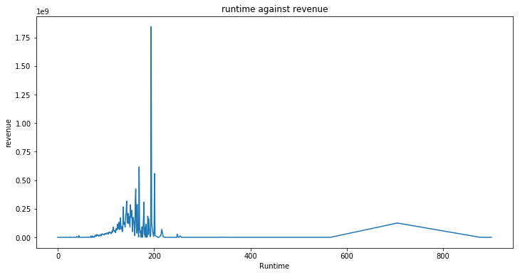

```python
plt.figure(figsize = (12,6))
plt.plot(mean_revenue_by_runtime.index, mean_revenue_by_runtime)

plt.title('runtime against revenue')
plt.xlabel('Runtime')
plt.ylabel('revenue')
plt.show()
```

```python
mean_revenue_by_release_year = df.groupby('release_year').mean()['revenue']
mean_revenue_by_release_year;
```

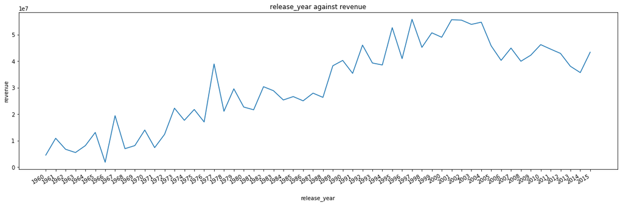

```python
# Plot release_year against revenue generated
plt.figure(figsize = (20,6))
plt.plot(mean_revenue_by_release_year.index, mean_revenue_by_release_year)
plt.gcf().autofmt_xdate()

plt.title('release_year against revenue')
plt.xlabel('release_year', labelpad = 20)
plt.ylabel('revenue')
plt.show()
```

### Conclusions

> This study also has some limitation as a result of the zeros value for budget and revenue column which is above 50% of there data